# Introduction to Programming

Hugo Lhuillier

Master in Economics, Sciences Po

# Formulas

# Formulas

- Formulas: used to specify models; encoded with `~`
- Ex: `y ~ x` stands for “`y` is explained by `x`”
- Use extensively for econometric analysis, but not only

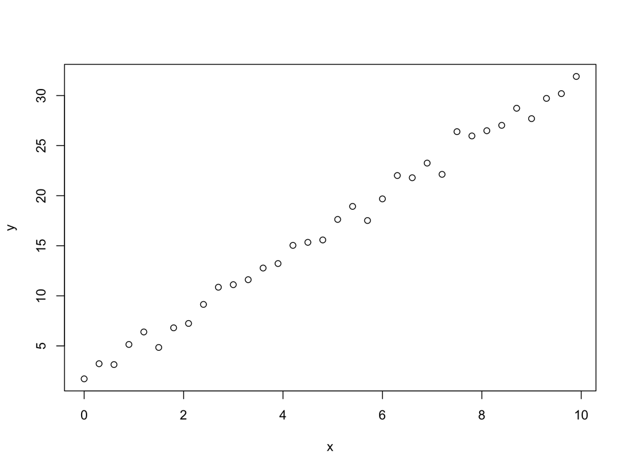

```r
x <- seq(from = 0, to = 10, by = 0.3)
y <- 2 + 3 * x + rnorm(length(x))
plot(y ~ x)
```

# Disclaimer

# Disclaimer

- Will not cover:
  - panel data (very similar to OLS)
  - time series (excellent tools from the `stats` and `tseries` packages)
  - quantile regressions

# Univariate Linear Regression

# Inroduction

- Interested in estimating the $\beta$s in
  $$y = X \beta + \epsilon$$
- Estimates: $\hat{\beta} = (X^T X)^{-1} X^T y$
- Fitted values: $\hat{y} = X \hat{\beta}$
- Residuals: $\hat{\epsilon} = y - \hat{y}$
- Residual sum of squares: $RSS = \hat{\epsilon}^T \hat{\epsilon}$

# Regressions in `R`

- Models are estimated by calling a model-fitting function
- Most of them take two key arguments: the formula and the data
- For **l**inear **m**odels fitted with OLS: `lm()`
- These functions return a *fitted-model object*, from which can extract the point estimates, compute predicted values, etc.

# Linear regression: example

- Data from Stock & Watson (2007) on subscriptions to economics journals at US libraries for the year 2000

```r
# do not forget library(tidyverse)
data(Journals, package = "AER")
journals <- as_tibble(Journals)
journals
```

```
## # A tibble: 180 x 10
##    title publisher society price pages charpp citations foundingyear  subs
##  * <chr> <fct>     <fct>   <int> <int>  <int>     <int>        <int> <int>
##  1 Asia… Blackwell no        123   440   3822        21         1986    14
##  2 Sout… So Afr e… no         20   309   1782        22         1986    59
##  3 Comp… Kluwer    no        443   567   2924        22         1987    17
##  4 MOCT… Kluwer    no        276   520   3234        22         1991     2
##  5 Jour… Elsevier  no        295   791   3024        24         1972    96
##  6 Labo… Elsevier  no        344   609   2967        24         1994    15
##  7 Envi… Cambridg… no         90   602   3185        24         1995    14
##  8 Revi… Elsevier  no        242   665   2688        27         1968   202
##  9 Econ… Kluwer    no        226   243   3010        28         1987    46
## 10 Metr… Blackwell no        262   386   2501        30         1949    46
## # ... with 170 more rows, and 1 more variable: field <fct>
```

- Goal: estimate the effect of the price per citation on the number of library subscriptions

# Linear regression: example

- **Ex**: compute a new variable, the price per citation, compute some summary statistics, and plot the number of subscriptions againsts the price per citation. Combine the summary statistics and the plot to describe what type of model we should use.

# Linear regression: example

```r
journals <- journals %>%
            mutate(citeprice = price / citations)
summary(select(journals,subs,price,citeprice))
```

```
##       subs            price          citeprice
##  Min.   :   2.0   Min.   :  20.0   Min.   : 0.005223
##  1st Qu.:  52.0   1st Qu.: 134.5   1st Qu.: 0.464495
##  Median : 122.5   Median : 282.0   Median : 1.320513
##  Mean   : 196.9   Mean   : 417.7   Mean   : 2.548455
##  3rd Qu.: 268.2   3rd Qu.: 540.8   3rd Qu.: 3.440171
##  Max.   :1098.0   Max.   :2120.0   Max.   :24.459459
```

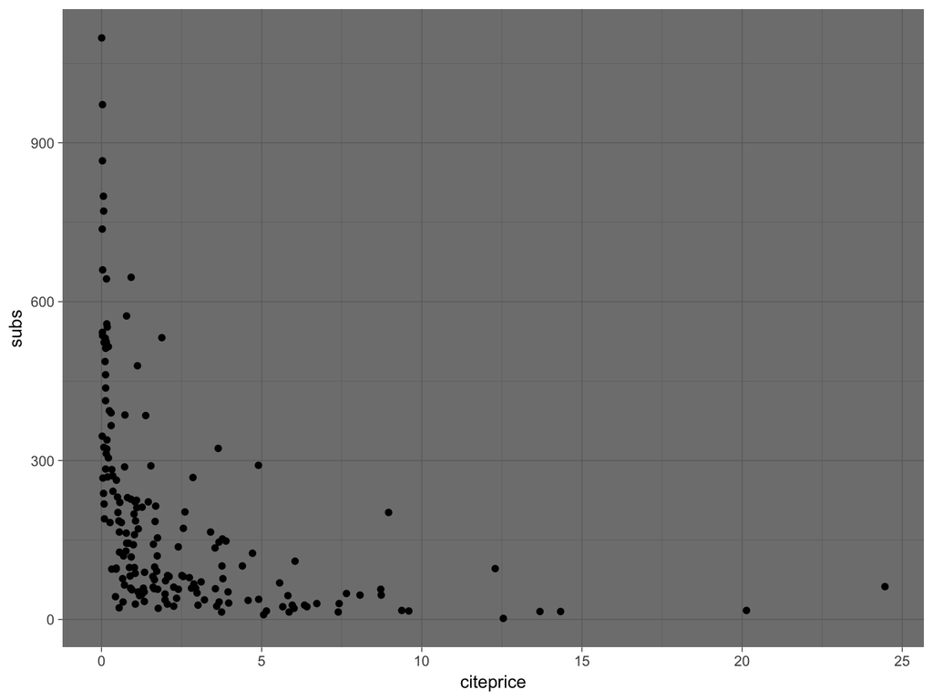

```r
ggplot(journals) + geom_point(aes(x = citeprice, y = subs))
```

# Linear regression: example

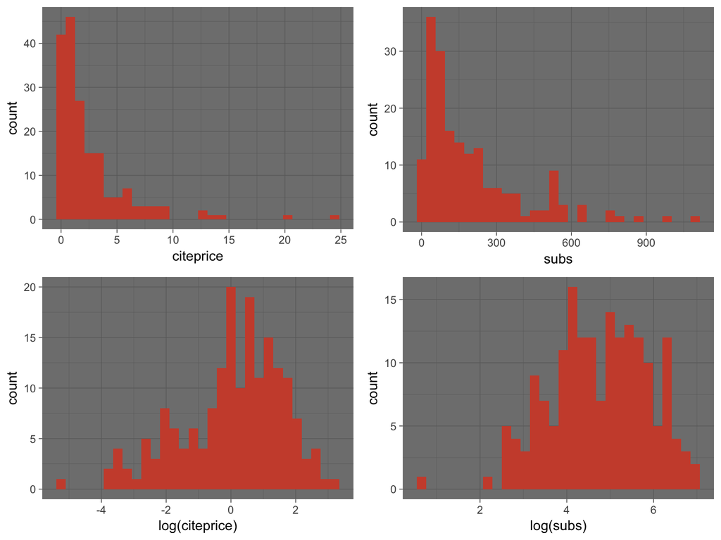

- Wide range of the variables + big skewness: linear log-log model
$$\log(subs_i) = \beta_1 + \beta_2 \log(citeprice_i) + \varepsilon_i$$

# Fitted a liner model with OLS

- To estimate our model and store it in `jour_lm`

```r
jour_lm <- journals %>%
            lm(log(subs) ~ log(citeprice), data = .)
summary(jour_lm) # prints the result of the estimation
```

```
##
## Call:
## lm(formula = log(subs) ~ log(citeprice), data = .)
##
## Residuals:
##      Min       1Q   Median       3Q      Max
## -2.72478 -0.53609  0.03721  0.46619  1.84808
##
## Coefficients:
##                Estimate Std. Error t value Pr(>|t|)
## (Intercept)     4.76621    0.05591   85.25   <2e-16 ***
## log(citeprice) -0.53305    0.03561  -14.97   <2e-16 ***
## ---
## Signif. codes:  0 '***' 0.001 '**' 0.01 '*' 0.05 '.' 0.1 ' ' 1
##
## Residual standard error: 0.7497 on 178 degrees of freedom
## Multiple R-squared:  0.5573, Adjusted R-squared:  0.5548
## F-statistic:   224 on 1 and 178 DF,  p-value: < 2.2e-16
```

# Fitted a linear model with OLS

- **Note**: `ggplot2` also has a linear fitting function that directly plots the output

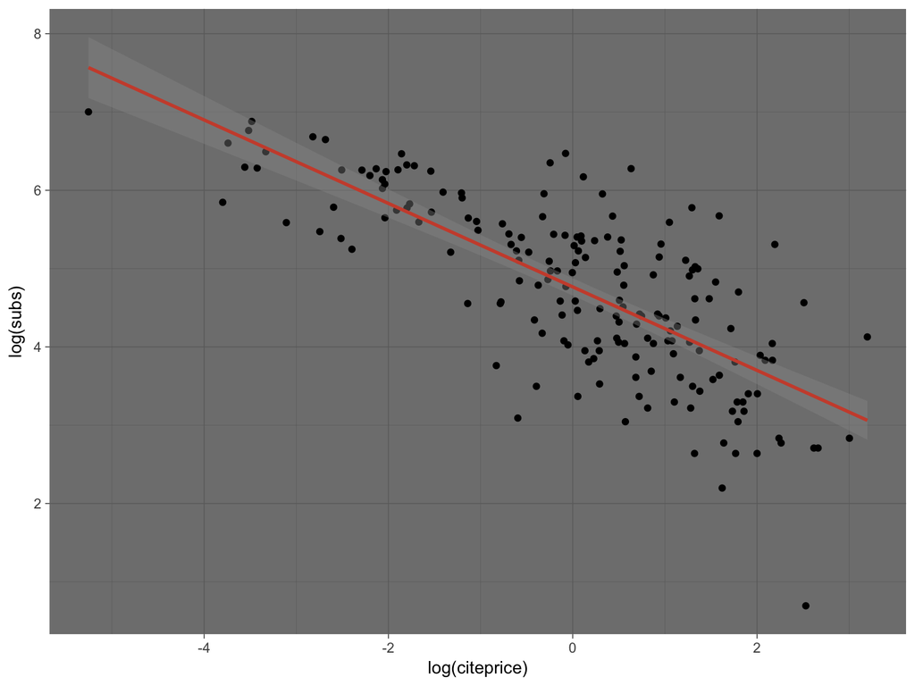

```r
ggplot(journals, aes(x = log(citeprice), y = log(subs))) +
  geom_point() +
  stat_smooth(method = "lm", col = "tomato3")
```

# Functions working on linear models

- `coef()`: extracts the regression coefficients
- `confint()`: returns confidence intervals on the estimates
- `residuals()`: extracts the residuals
- `fitted()`: returns the fitted values
- `predict()`: computes predictions for new data
- `plot()`: produces diagnostic plots

# Functions working on linear models

```r
coef(jour_lm)                   # extract the coefficients
```

```
##    (Intercept) log(citeprice)
##      4.7662121     -0.5330535
```

```r
confint(jour_lm, level = 0.95)  # compute the 95% ci
```

```
##                     2.5 %     97.5 %
## (Intercept)     4.6558822  4.8765420
## log(citeprice) -0.6033319 -0.4627751
```

```r
# build a new data set and predict the # of subscriptions based on our model
journals_new <- tribble(
  ~citeprice,
  1.80,
  2.0,
  2.11
)
predict(jour_lm, newdata = journals_new)
```

```
##        1        2        3
## 4.452890 4.396728 4.368188
```

# Diagnostic plots

- Base `R` plot functions offer some diagnostic plots
  1. residuals vs. fitted values
  2. QQ plot for normality
  3. Scale-location plot
  4. Cook’s distance, leverage and residuals

# Residuals vs. fitted values plot

- Useful to test $\mathbb{E}(\varepsilon \mid X) = 0$
- This plot will tell you if there are systematic variations in the residuals

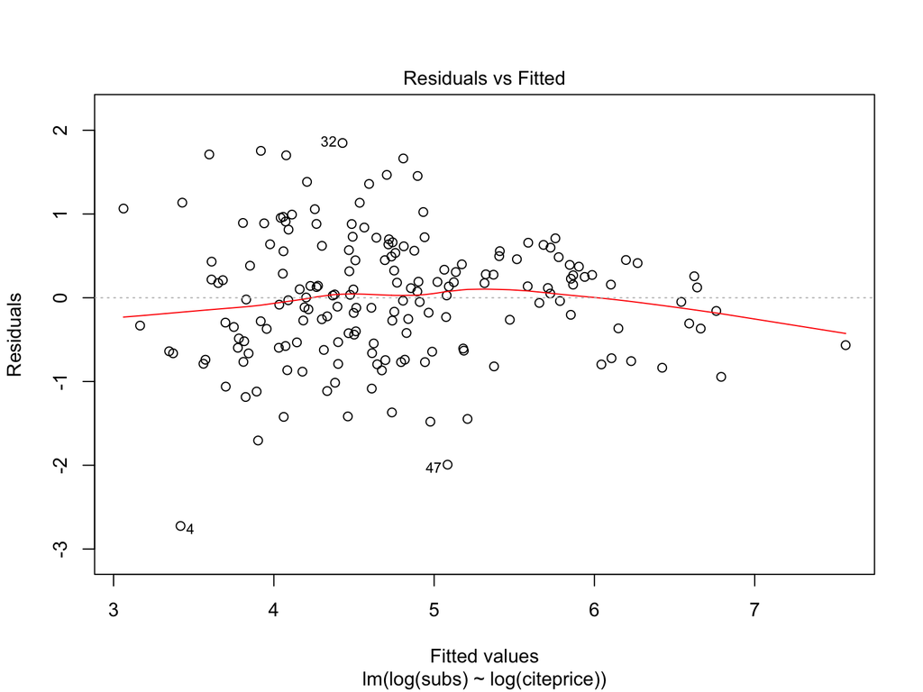

```r
plot(jour_lm, which = 1)
```

# QQ plot for normality

- Key assumption when doing OLS: the error terms are i.i.d. and normally distributed
- QQ plot for normality: compares the residuals vs. “ideal” normal observations

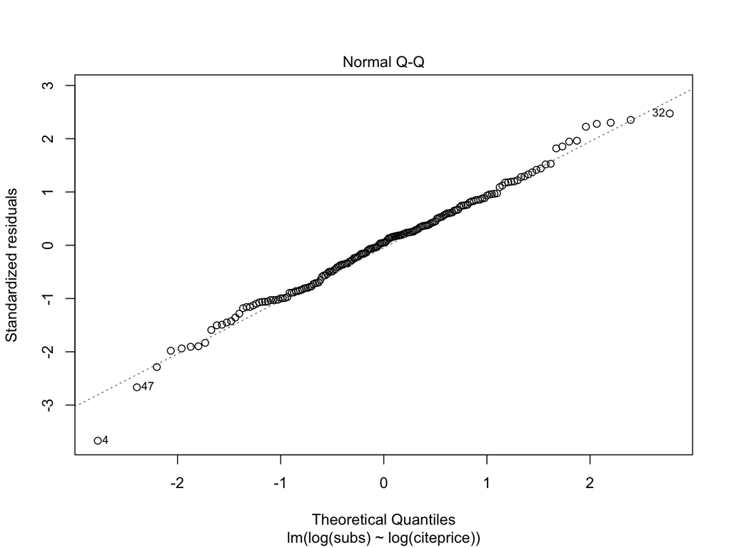

```r
plot(jour_lm, which = 2)
```

# Scale-location plot

- Depicts $\sqrt{\mid \hat{y}_i - y_i \mid}$, the standardized residuals, against $\hat{y}_i$
- Test whether the variances of the error terms are identical, i.e. test for homoskedasticity

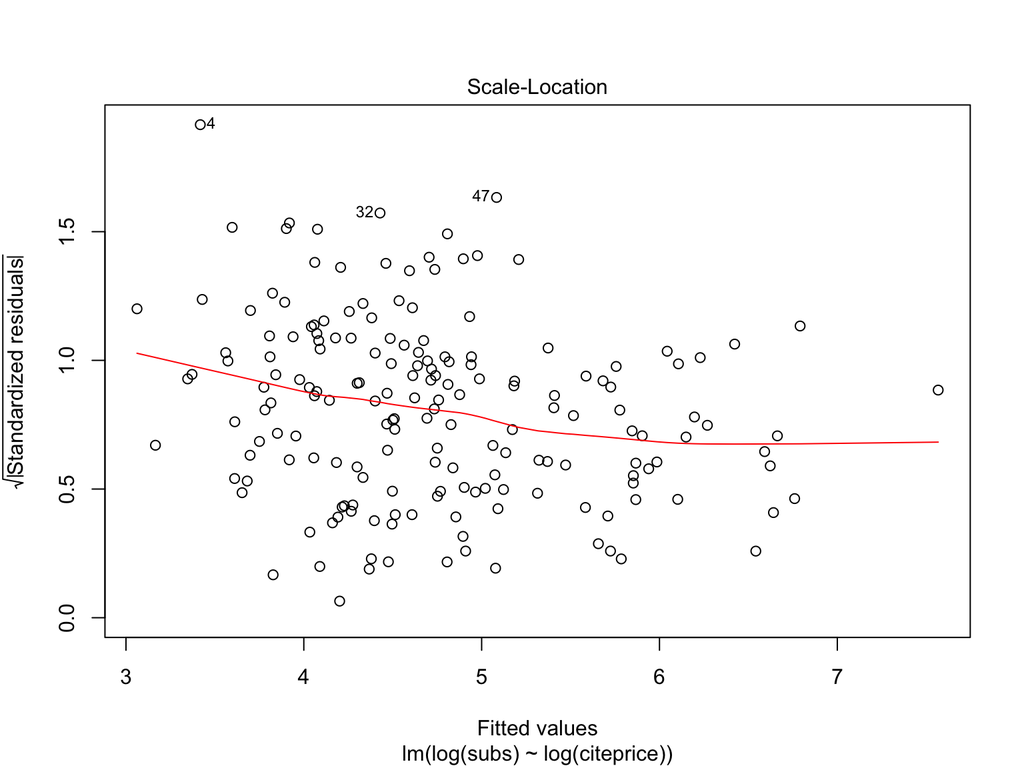

```r
plot(jour_lm, which = 3)
```

- Alternatively, can use the Breusch-Pagan test woth `bptest(jour_lm)`

# Testing linear hypothesis

- `summary()` indicates individual significance of each regressor and joint significance of all regressors
- `linearHypothesis()` from the `car` package allows to test for more general hypothesis
- First argument: a fitted-model object
- Second argument can be of two types:
  1. Specify the linear hypothesis with a string
  2. Specify an `hypothesis.matrix` ($R$) and a `rhs` vector ($r$), as in

  $$H_0: R \beta = r$$
- Returns the models (restricted and non-restricted), along with their degrees of freedom, RSS, and associated $F$ statistic

# Testing linear hypothesis

- **Ex:** test the hypothesis that the elasticity of the number of library subscriptions with respect to the price per citation equals −0.5, i.e. $H_0: \beta_2 = -0.5$

```r
library(car)
```

```r
linearHypothesis(jour_lm, "log(citeprice) = -0.5")
```

```
## Linear hypothesis test
##
## Hypothesis:
## log(citeprice) = - 0.5
##
## Model 1: restricted model
## Model 2: log(subs) ~ log(citeprice)
##
##   Res.Df    RSS Df Sum of Sq      F Pr(>F)
## 1    179 100.54
## 2    178 100.06  1   0.48421 0.8614 0.3546
```

```r
# alternatively
linearHypothesis(jour_lm, hypothesis.matrix = c(0, 1), rhs = -0.5)
```

# Multivariate Linear Regression

# Multivariate Linear Regression

- To illustrate: CPS of 1988

```r
data("CPS1988", package = "AER")
cps <- as_tibble(CPS1988)
cps
```

```
## # A tibble: 28,155 x 7
##     wage education experience ethnicity smsa  region    parttime
##  * <dbl>     <int>      <int> <fct>     <fct> <fct>     <fct>
##  1  355.         7         45 cauc      yes   northeast no
##  2  123.        12          1 cauc      yes   northeast yes
##  3  370.         9          9 cauc      yes   northeast no
##  4  755.        11         46 cauc      yes   northeast no
##  5  594.        12         36 cauc      yes   northeast no
##  6  377.        16         22 cauc      yes   northeast no
##  7  285.         8         51 cauc      yes   northeast no
##  8  561.        12         34 cauc      yes   northeast no
##  9  264.        12          0 cauc      yes   northeast no
## 10 1644.        14         18 cauc      yes   northeast no
## # ... with 28,145 more rows
```

# Multivariate Linear Regression

- Interested in the model
  $$\log(wage_i) = \beta_1 + \beta_2 \, exp_i + \beta_3 \, exp_i^2 + \beta_4 \, education_i + \\ \beta_5 \, ethnicity_i + \varepsilon_i$$

```r
cps_lm <- cps %>%
          lm(log(wage) ~ experience + I(experience^2) + education + ethnicity, data = .)
```

# Multivariate Linear Regression

```r
summary(cps_lm)
```

```
##
## Call:
## lm(formula = log(wage) ~ experience + I(experience^2) + education +
##     ethnicity, data = .)
##
## Residuals:
##     Min      1Q  Median      3Q     Max
## -2.9428 -0.3162  0.0580  0.3756  4.3830
##
## Coefficients:
##                   Estimate Std. Error t value Pr(>|t|)
## (Intercept)      4.321e+00  1.917e-02  225.38   <2e-16 ***
## experience       7.747e-02  8.800e-04   88.03   <2e-16 ***
## I(experience^2) -1.316e-03  1.899e-05  -69.31   <2e-16 ***
## education        8.567e-02  1.272e-03   67.34   <2e-16 ***
## ethnicityafam   -2.434e-01  1.292e-02  -18.84   <2e-16 ***
## ---
## Signif. codes:  0 '***' 0.001 '**' 0.01 '*' 0.05 '.' 0.1 ' ' 1
##
## Residual standard error: 0.5839 on 28150 degrees of freedom
## Multiple R-squared:  0.3347, Adjusted R-squared:  0.3346
## F-statistic:  3541 on 4 and 28150 DF,  p-value: < 2.2e-16
```

# Dummy variables

- In the above summary, have `ethnicityafam` because `cauc` is taken as the reference category
- Unordered factors are always handled like this by `R`: `R` always creates a reference category
- Can modify the reference category with `relevel(<factor>, ref = <new_reference>)`
- Alternatively, can remove the intercept to avoid the multicolinearity with `-1`

```r
# use afam as reference category
lm(log(wage) ~ experience + I(experience^2) + education + relevel(ethnicity, ref = "afam"), data = cps)
# remove the intercept
lm(log(wage) ~ experience + I(experience^2) + education + ethnicity - 1, data = cps)
```

# The function `I()`

- Within formulas, the mathematical operators have different meaning. For `x` and `y` two variables that are respectively continuous and discrete,
  - `x + y`: add the two variables in the formula
  - `x : y`: add the interaction between `x` and `y`
  - `x * y`: add the two variables and their interaction, i.e. `x + y + x : y`
  - `y / x`: compute an explicit slope estimate for each category of `y`
  - `(a + b + c)^2`: add all two-way interactions betwee `a`, `b` and `c`
- To keep their arithmetic meaning, need to enclose them inside a `R` function, e.g. `log(x1 * x2)` would work; if does not require a transformation, `I(x1 * x2)` is used as the “identity” function

# Interactions

- **Ex**: to study the interaction between education and ethnicity

```r
cps_int <- cps %>%
           lm(log(wage) ~ experience + I(experience^2) + education * ethnicity, data = .)
summary(cps_int)
```

```
##
## Call:
## lm(formula = log(wage) ~ experience + I(experience^2) + education *
##     ethnicity, data = .)
##
## Residuals:
##     Min      1Q  Median      3Q     Max
## -2.9451 -0.3162  0.0578  0.3761  4.3929
##
## Coefficients:
##                           Estimate Std. Error t value Pr(>|t|)
## (Intercept)              4.313e+00  1.959e-02 220.170   <2e-16 ***
## experience               7.752e-02  8.803e-04  88.063   <2e-16 ***
## I(experience^2)         -1.318e-03  1.901e-05 -69.339   <2e-16 ***
## education                8.631e-02  1.309e-03  65.944   <2e-16 ***
## ethnicityafam           -1.239e-01  5.903e-02  -2.099   0.0358 *
## education:ethnicityafam -9.648e-03  4.651e-03  -2.074   0.0380 *
## ---
## Signif. codes:  0 '***' 0.001 '**' 0.01 '*' 0.05 '.' 0.1 ' ' 1
##
## Residual standard error: 0.5839 on 28149 degrees of freedom
## Multiple R-squared:  0.3348, Adjusted R-squared:  0.3347
## F-statistic:  2834 on 5 and 28149 DF,  p-value: < 2.2e-16
```

```r
# the last terms would be identical to
# education + ethnicity + education : ethnicity
```

# Interactions

- **Ex**: could also fit separate regressions for African-Americans and Caucasians
- Below, `/` specifies that the terms within parentheses are nested within `ethnicity`

```r
cps_sep <- cps %>%
           lm(log(wage) ~ ethnicity / (experience + I(experience^2) + education) - 1, data = .)
summary(cps_sep)
```

```
##
## Call:
## lm(formula = log(wage) ~ ethnicity/(experience + I(experience^2) +
##     education) - 1, data = .)
##
## Residuals:
##     Min      1Q  Median      3Q     Max
## -2.9353 -0.3168  0.0571  0.3754  4.4418
##
## Coefficients:
##                                 Estimate Std. Error t value Pr(>|t|)
## ethnicitycauc                  4.310e+00  1.977e-02  217.97   <2e-16 ***
## ethnicityafam                  4.159e+00  7.330e-02   56.74   <2e-16 ***
## ethnicitycauc:experience       7.923e-02  9.231e-04   85.84   <2e-16 ***
## ethnicityafam:experience       6.190e-02  2.940e-03   21.05   <2e-16 ***
## ethnicitycauc:I(experience^2) -1.360e-03  2.001e-05  -67.97   <2e-16 ***
## ethnicityafam:I(experience^2) -9.415e-04  6.069e-05  -15.51   <2e-16 ***
## ethnicitycauc:education        8.575e-02  1.313e-03   65.29   <2e-16 ***
## ethnicityafam:education        8.654e-02  5.099e-03   16.97   <2e-16 ***
## ---
## Signif. codes:  0 '***' 0.001 '**' 0.01 '*' 0.05 '.' 0.1 ' ' 1
##
## Residual standard error: 0.5835 on 28147 degrees of freedom
## Multiple R-squared:  0.9912, Adjusted R-squared:  0.9912
## F-statistic: 3.954e+05 on 8 and 28147 DF,  p-value: < 2.2e-16
```

# Hypothesis testing

```r
# by default, test = 0
linearHypothesis(cps_lm,
                  hypothesis.matrix = c(0, 1, 1, 0, 0))
```

```
## Linear hypothesis test
##
## Hypothesis:
## experience  + I(experience^2) = 0
##
## Model 1: restricted model
## Model 2: log(wage) ~ experience + I(experience^2) + education + ethnicity
##
##   Res.Df     RSS Df Sum of Sq      F    Pr(>F)
## 1  28151 12259.9
## 2  28150  9598.6  1    2661.3 7804.7 < 2.2e-16 ***
## ---
## Signif. codes:  0 '***' 0.001 '**' 0.01 '*' 0.05 '.' 0.1 ' ' 1
```

# WLS, GLS and FGLS

# Weighted least squares

- In our work on the effect of price on journals’ subscriptions, our data featured heteroskedasticity

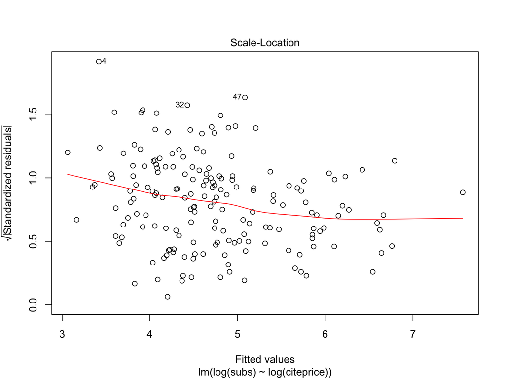

```r
plot(jour_lm, which = 3)
```

# Weighted least squares

- Standard remedy: weighted least squares
- *Test 1*: use the inverse of the square of the price per citation as a weight

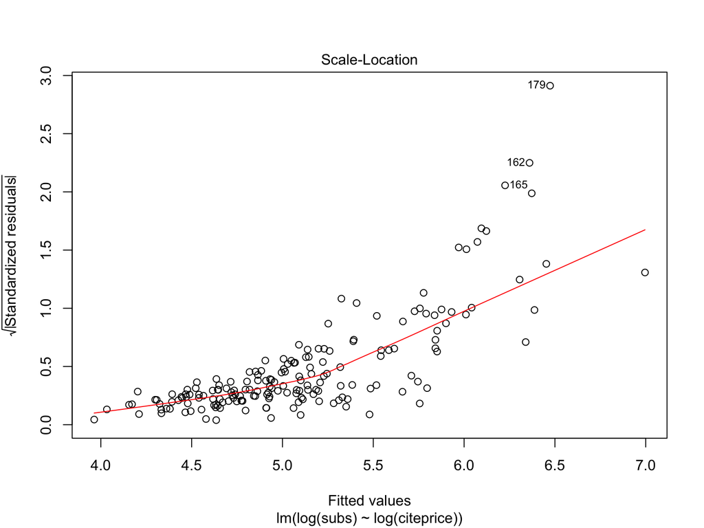

```r
jour_wls1 <- journals %>%
             lm(log(subs) ~ log(citeprice), data = ., weights = 1 / citeprice^2)
plot(jour_wls1, which = 3)
```

# Feasible generalized least squares

- Very frequently: no clue what weight to use, leading to the feasible generalized least square (FGLS)
  1. fit the model as if were homoskedastic
     $$\log(subs_i) = \beta_1 + \beta_2 citeprice_i + \varepsilon_i$$
  2. fit a linear model on the squared residuals
     $$\log((subs_i - \hat{\beta}_1 - \hat{\beta}_2 citeprice_i)^2) = \alpha_1 + \alpha_2 citeprice_i$$
  3. fit the model, using as weights the predicted values of residuals

# Feasible generalized least squares

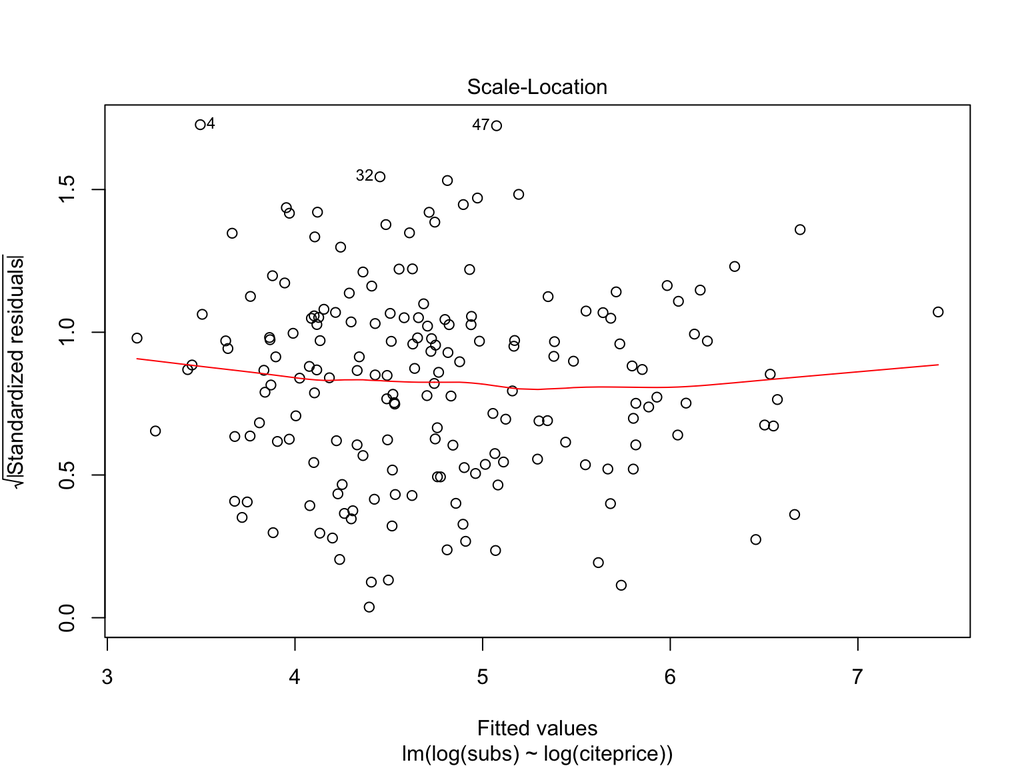

```r
# first step already done
# jour_lm <- lm(log(subs) ~ log(citeprice), data = journals)
aux_reg <- lm(log(residuals(jour_lm)^2) ~ log(citeprice), data = journals)
jour_fgls <- lm(log(subs) ~ log(citeprice), data = journals, weights = 1 / exp(fitted(aux_reg)))
plot(jour_fgls, which = 3)
```

# Models of Microeconometrics

# Introduction

- Probit, logit and similar models are referred to as generalized linear models (GLMs)
- Most of the time, closed-form solutions for the estimator do not exist, and the estimation occurs via some numerical method
- In `R`, most of these estimation procedures are already coded for you in the function `glm()`

# Binary dependent variables

- Logit and probit regressions take the form:
  $$\mathbb{E}(y_i \mid x_i) = p_i = F(x_i^T \beta)$$
  where $F$ is the standard normal cdf in the probit case, and the logistic CDF in the logit case
- `glm()` has two key arguments:
  1. `family` (here, the family is binomial)
  2. `link` (logit, or probit)

# Binary dependent variables

- **Ex**: female labor force partitipcation, based on Switzerland data

```r
data("SwissLabor", package = "AER")
labor <- as_tibble(SwissLabor)
labor
```

```
## # A tibble: 872 x 7
##    participation income   age education youngkids oldkids foreign
##  * <fct>          <dbl> <dbl>     <dbl>     <dbl>   <dbl> <fct>
##  1 no              10.8  3.00        8.        1.      1. no
##  2 yes             10.5  4.50        8.        0.      1. no
##  3 no              11.0  4.60        9.        0.      0. no
##  4 no              11.1  3.10       11.        2.      0. no
##  5 no              11.1  4.40       12.        0.      2. no
##  6 yes             11.0  4.20       12.        0.      1. no
##  7 no              11.5  5.10        8.        0.      0. no
##  8 yes             10.5  3.20        8.        0.      2. no
##  9 no              10.6  3.90       12.        0.      0. no
## 10 no              10.5  4.30       11.        0.      2. no
## # ... with 862 more rows
```

- Model:
  $$\text{Prob}(participation_i = yes) = \beta_1 + \beta_2 income_i + \beta_3 education_i + \\
  \beta_4 age_i + \beta_5 age_i^2 + \beta_6 youngkids_i + \\
  \beta_7 oldkids_i + \beta_8 foreign_i + \varepsilon_i$$

# Binary dependent variables

- Before running the model, can use a spinogram to have an idea of what the data looks like

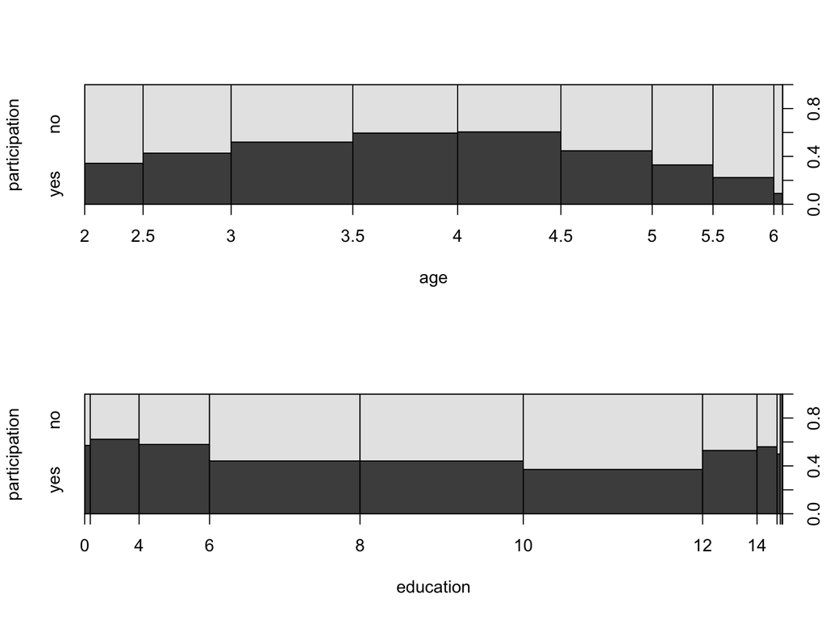

```r
# Base R plotting
par(mfrow = c(2, 1))
plot(participation ~ age, data = labor, ylevels = 2:1)
plot(participation ~ education, data = labor, ylevels = 2:1)
```

# Probit

- In `R`

```r
labor_probit <- labor %>%
  glm(participation ~ . + I(age^2), data = ., family = binomial(link = "probit"))
summary(labor_probit)
```

```
##
## Call:
## glm(formula = participation ~ . + I(age^2), family = binomial(link = "probit"),
##     data = .)
##
## Deviance Residuals:
##     Min       1Q   Median       3Q      Max
## -1.9191  -0.9695  -0.4792   1.0209   2.4803
##
## Coefficients:
##             Estimate Std. Error z value Pr(>|z|)
## (Intercept)  3.74909    1.40695   2.665  0.00771 **
## income      -0.66694    0.13196  -5.054 4.33e-07 ***
## age          2.07530    0.40544   5.119 3.08e-07 ***
## education    0.01920    0.01793   1.071  0.28428
## youngkids   -0.71449    0.10039  -7.117 1.10e-12 ***
## oldkids     -0.14698    0.05089  -2.888  0.00387 **
## foreignyes   0.71437    0.12133   5.888 3.92e-09 ***
## I(age^2)    -0.29434    0.04995  -5.893 3.79e-09 ***
## ---
## Signif. codes:  0 '***' 0.001 '**' 0.01 '*' 0.05 '.' 0.1 ' ' 1
##
## (Dispersion parameter for binomial family taken to be 1)
##
##     Null deviance: 1203.2  on 871  degrees of freedom
## Residual deviance: 1017.2  on 864  degrees of freedom
## AIC: 1033.2
##
## Number of Fisher Scoring iterations: 4
```

# Marginal effects

- As you know, efects in probit regressions vary with the regressors:
  $$\frac{\partial \mathbb{E} (y_i \mid x_i)}{\partial x_{i,j}} = \phi(x_i^T \beta) \beta_j$$
- Can report sample average marginal effects:
  $$\frac{\partial \mathbb{E} (y_i \mid x_i)}{\partial x_{i,j}} \approx \frac{1}{n} \sum_{i=1}^n \phi(x_i^T \hat{\beta}) \hat{\beta}_j$$

```r
avg <- mean(dnorm(predict(labor_probit, type = "link")))
avg * coef(labor_probit)
```

```
##  (Intercept)       income          age    education    youngkids
##  1.241929965 -0.220931858  0.687466185  0.006358743 -0.236682273
##      oldkids   foreignyes     I(age^2)
## -0.048690170  0.236644422 -0.097504844
```

# Marginal effects

- Alternatively, can evaluate the partial derivative at the average regressor
  $$\frac{\partial \mathbb{E} (y_i \mid x_i)}{\partial x_{i,j}} \approx \phi( \bar{x}^T \hat{\beta}) \hat{\beta}_j$$
- Problem: how to deal with factors?
- Solution: report average effects for all levels of the factors

```r
av <- labor %>%
      group_by(foreign) %>%
      summarize(income = mean(income),
                age = mean(age),
                education = mean(education),
                youngkids = mean(youngkids),
                oldkids = mean(oldkids)) %>%
      predict(labor_probit, newdata = ., type = "link") %>%
      dnorm(.)
# swiss
av[1] * coef(labor_probit)[-7]
```

```
##  (Intercept)       income          age    education    youngkids
##  1.495566126 -0.266052203  0.827865635  0.007657373 -0.285019285
##      oldkids     I(age^2)
## -0.058634038 -0.117418007
```

# Multinomial, Ordinal & Tobit regressions

- Multinomial, ordinal and Tobit regressions are implemented in `R`
- Multinomial: `multinom(<formula>, data = <data>)` from the `nnet`package
- Ordinal: `polr(<formula>, data = <data>)` from the `MASS` package
- Tobit: `tobit(<formulas>, data = <data>)` from the `AER` package (or `survival`)

# Multinomial, Ordinal & Tobit regressions: visualization

- As for the binary models, `R` offers some visualization tools

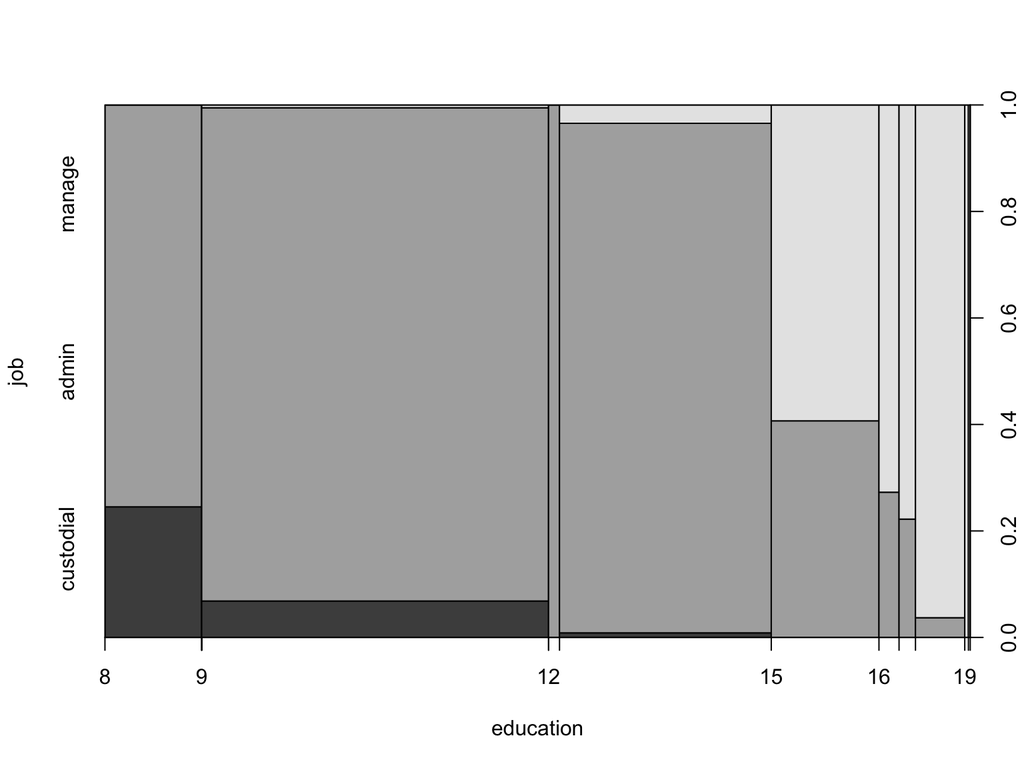

```r
data("BankWages", package = "AER")
jobs <- as_tibble(BankWages)
plot(job ~ education, data = jobs)
```